# sklearn.svm.OneClassSVM

**class*sklearn.svm.OneClassSVM(*, *kernel='rbf'*, *degree=3*, *gamma='scale'*, *coef0=0.0*, *tol=0.001*, *nu=0.5*, *shrinking=True*, *cache_size=200*, *verbose=False*, *max_iter=-1*)[[source]](https://github.com/scikit-learn/scikit-learn/blob/f3f51f9b6/sklearn/svm/_classes.py#L1453)**

Unsupervised Outlier Detection.

Estimate the support of a high-dimensional distribution.

The implementation is based on libsvm.

Read more in the User Guide.

**Parameters:**

**kernel**{‘linear’, ‘poly’, ‘rbf’, ‘sigmoid’, ‘precomputed’} or callable, default=’rbf’**

Specifies the kernel type to be used in the algorithm. If none is given, ‘rbf’ will be used. If a callable is given it is used to precompute the kernel matrix.

**degree**int, default=3**

Degree of the polynomial kernel function (‘poly’). Ignored by all other kernels.

**gamma**{‘scale’, ‘auto’} or float, default=’scale’**

Kernel coefficient for ‘rbf’, ‘poly’ and ‘sigmoid’.

- if `gamma='scale'` (default) is passed then it uses 1 / (n_features * X.var()) as value of gamma,
- if ‘auto’, uses 1 / n_features.

Changed in version 0.22: The default value of `gamma` changed from ‘auto’ to ‘scale’.

**coef0**float, default=0.0**

Independent term in kernel function. It is only significant in ‘poly’ and ‘sigmoid’.

**tol**float, default=1e-3**

Tolerance for stopping criterion.

**nu**float, default=0.5**

An upper bound on the fraction of training errors and a lower bound of the fraction of support vectors. Should be in the interval (0, 1]. By default 0.5 will be taken.

**shrinking**bool, default=True**

Whether to use the shrinking heuristic. See the User Guide.

**cache_size**float, default=200**

Specify the size of the kernel cache (in MB).

**verbose**bool, default=False**

Enable verbose output. Note that this setting takes advantage of a per-process runtime setting in libsvm that, if enabled, may not work properly in a multithreaded context.

**max_iter**int, default=-1**

Hard limit on iterations within solver, or -1 for no limit.

**Attributes:**

**class_weight_**ndarray of shape (n_classes,)**

Multipliers of parameter C for each class. Computed based on the `class_weight` parameter.

**`coef_`ndarray of shape (1, n_features)**

Weights assigned to the features when `kernel="linear"`.

**dual_coef_**ndarray of shape (1, n_SV)**

Coefficients of the support vectors in the decision function.

**fit_status_**int**

0 if correctly fitted, 1 otherwise (will raise warning)

**intercept_**ndarray of shape (1,)**

Constant in the decision function.

**n_features_in_**int**

Number of features seen during fit.

New in version 0.24.

**feature_names_in_**ndarray of shape (`n_features_in_`,)**

Names of features seen during fit. Defined only when `X` has feature names that are all strings.

New in version 1.0.

**n_iter_**int**

Number of iterations run by the optimization routine to fit the model.

New in version 1.1.

**`n_support_`ndarray of shape (n_classes,), dtype=int32**

Number of support vectors for each class.

**offset_**float**

Offset used to define the decision function from the raw scores. We have the relation: decision_function = score_samples - `offset_`. The offset is the opposite of `intercept_` and is provided for consistency with other outlier detection algorithms.

New in version 0.20.

**shape_fit_**tuple of int of shape (n_dimensions_of_X,)**

Array dimensions of training vector `X`.

**support_**ndarray of shape (n_SV,)**

Indices of support vectors.

**support_vectors_**ndarray of shape (n_SV, n_features)**

Support vectors.

See also

**`sklearn.linear_model.SGDOneClassSVM`**

Solves linear One-Class SVM using Stochastic Gradient Descent.

**`sklearn.neighbors.LocalOutlierFactor`**

Unsupervised Outlier Detection using Local Outlier Factor (LOF).

**`sklearn.ensemble.IsolationForest`**

Isolation Forest Algorithm.

#### Examples

```
>>> from sklearn.svm import OneClassSVM
>>> X = [[0], [0.44], [0.45], [0.46], [1]]
>>> clf = OneClassSVM(gamma='auto').fit(X)
>>> clf.predict(X)
array([-1,  1,  1,  1, -1])
>>> clf.score_samples(X)
array([1.7798..., 2.0547..., 2.0556..., 2.0561..., 1.7332...])
```

#### Methods

| `decision_function`(X) | Signed distance to the separating hyperplane. |
| --- | --- |
| `fit`(X[, y, sample_weight]) | Detect the soft boundary of the set of samples X. |
| `fit_predict`(X[, y]) | Perform fit on X and returns labels for X. |
| `get_params`([deep]) | Get parameters for this estimator. |
| `predict`(X) | Perform classification on samples in X. |
| `score_samples`(X) | Raw scoring function of the samples. |
| `set_params`(**params) | Set the parameters of this estimator. |

**property*coef_**

Weights assigned to the features when `kernel="linear"`.

**decision_function(*X*)[[source]](https://github.com/scikit-learn/scikit-learn/blob/f3f51f9b6/sklearn/svm/_classes.py#L1670)**

Signed distance to the separating hyperplane.

Signed distance is positive for an inlier and negative for an outlier.

**Parameters:**

**X**array-like of shape (n_samples, n_features)**

The data matrix.

**Returns:**

**dec**ndarray of shape (n_samples,)**

Returns the decision function of the samples.

**fit(*X*, *y=None*, *sample_weight=None*, **params)[[source]](https://github.com/scikit-learn/scikit-learn/blob/f3f51f9b6/sklearn/svm/_classes.py#L1624)**

Detect the soft boundary of the set of samples X.

**Parameters:**

**X**{array-like, sparse matrix} of shape (n_samples, n_features)**

Set of samples, where `n_samples` is the number of samples and `n_features` is the number of features.

**y**Ignored**

Not used, present for API consistency by convention.

**sample_weight**array-like of shape (n_samples,), default=None**

Per-sample weights. Rescale C per sample. Higher weights force the classifier to put more emphasis on these points.

**paramsdict**

Additional fit parameters.

Deprecated since version 1.0: The `fit` method will not longer accept extra keyword parameters in 1.2. These keyword parameters were already discarded.

**Returns:**

**self**object**

Fitted estimator.

#### Notes

If X is not a C-ordered contiguous array it is copied.

**fit_predict(*X*, *y=None*)[[source]](https://github.com/scikit-learn/scikit-learn/blob/f3f51f9b6/sklearn/base.py#L956)**

Perform fit on X and returns labels for X.

Returns -1 for outliers and 1 for inliers.

**Parameters:**

**X**{array-like, sparse matrix} of shape (n_samples, n_features)**

The input samples.

**y**Ignored**

Not used, present for API consistency by convention.

**Returns:**

**y**ndarray of shape (n_samples,)**

1 for inliers, -1 for outliers.

**get_params(*deep=True*)[[source]](https://github.com/scikit-learn/scikit-learn/blob/f3f51f9b6/sklearn/base.py#L194)**

Get parameters for this estimator.

**Parameters:**

**deep**bool, default=True**

If True, will return the parameters for this estimator and contained subobjects that are estimators.

**Returns:**

**params**dict**

Parameter names mapped to their values.

**property*n_support_**

Number of support vectors for each class.

**predict(*X*)[[source]](https://github.com/scikit-learn/scikit-learn/blob/f3f51f9b6/sklearn/svm/_classes.py#L1703)**

Perform classification on samples in X.

For a one-class model, +1 or -1 is returned.

**Parameters:**

**X**{array-like, sparse matrix} of shape (n_samples, n_features) or (n_samples_test, n_samples_train)**

For kernel=”precomputed”, the expected shape of X is (n_samples_test, n_samples_train).

**Returns:**

**y_pred**ndarray of shape (n_samples,)**

Class labels for samples in X.

**score_samples(*X*)[[source]](https://github.com/scikit-learn/scikit-learn/blob/f3f51f9b6/sklearn/svm/_classes.py#L1688)**

Raw scoring function of the samples.

**Parameters:**

**X**array-like of shape (n_samples, n_features)**

The data matrix.

**Returns:**

**score_samples**ndarray of shape (n_samples,)**

Returns the (unshifted) scoring function of the samples.

**set_params(**params)[[source]](https://github.com/scikit-learn/scikit-learn/blob/f3f51f9b6/sklearn/base.py#L218)**

Set the parameters of this estimator.

The method works on simple estimators as well as on nested objects (such as `Pipeline`). The latter have parameters of the form `<component>__<parameter>` so that it’s possible to update each component of a nested object.

**Parameters:**

**paramsdict**

Estimator parameters.

**Returns:**

**self**estimator instance**

Estimator instance.

## Examples using `sklearn.svm.OneClassSVM`

[figure not shown]

Libsvm GUI

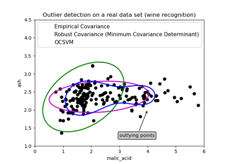

Outlier detection on a real data set

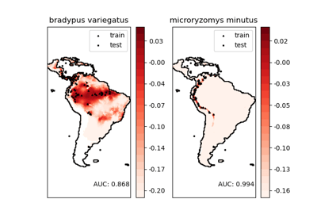

Species distribution modeling

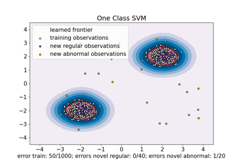

One-Class SVM versus One-Class SVM using Stochastic Gradient Descent

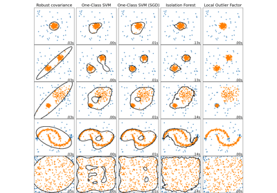

Comparing anomaly detection algorithms for outlier detection on toy datasets

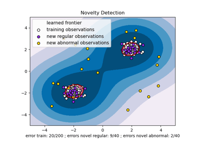

One-class SVM with non-linear kernel (RBF)

© 2007–2022 The scikit-learn developers  
Licensed under the 3-clause BSD License.  
https://scikit-learn.org/1.1/modules/generated/sklearn.svm.OneClassSVM.html